```r
rm(list=ls())
# Note the script should be run from the main directory of the repository.

# Checking if we are inside the correct folder, otherwise changing directory to the previous folder
file_exists<-"Session_Info"

if(file.exists(file_exists)){
  setwd("../")
  if(!file.exists("Code")){
    print("Please ensure that the script is run from the main repository folder")
  }
}else{
  if(!file.exists("Code")){
    print("Please ensure that the script is run from the main repository folder")
  }
}

# Functions and libraries ---------------------------
if(!require("tidyverse")){
  install.packages("tidyverse")
}
if(!require("plyr")){
  install.packages("plyr")
}
if(!require("dplyr")){
  install.packages("dplyr")
}
if(!require("tidyr")){
  install.packages("tidyr")
}
if(!require("ggeffects")){
  install.packages("effects")
}
if(!require("cowplot")){
  install.packages("cowplot")
}
if(!require("grid")){
  install.packages("grid")
}
if(!require("gridExtra")){
  install.packages("gridExtra")
}
if(!require("RColorBrewer")){
  install.packages("RColorBrewer")
}
if(!require("ggtext")){
  install.packages("ggtext")
}
if(!require("ggbreak")){
  install.packages("ggtext")
}

library(tidyverse)
library(plyr)
library(dplyr)
library(tidyr)
library(ggtext)
library(ggbreak)
library(cowplot)
library(ggeffects)
library(grid)
library(gridExtra)
library(RColorBrewer)

theme_plots<-theme(axis.text = element_text(size=14), axis.title = element_text(size=14, face="bold"), legend.text = element_text(size=12), strip.text = element_text(size=14), plot.title = element_text(size=14, face="bold"), panel.grid=element_line(colour="white"), panel.background = element_rect(fill="white") , axis.line = element_line(linewidth = 0.5, linetype = "solid", colour = "black"), strip.background = element_rect(fill="white"))

save_plot<-function(dir, width=15, height=10, ...){
  ggsave(dir, width = width, height = height, units = c("cm"))
}


Env<-c("No cadmium", "Cadmium")
names(Env)<-c("N", "Cd")

regimeTu<-c("Tu no cadmium", "Tu cadmium")
names(regimeTu)<-c("SR1", "SR2")

regimeTe<-c("Te no cadmium", "Te cadmium")
names(regimeTe)<-c("SR4", "SR5")

colors_comb<-brewer.pal(name = "Spectral", 4)

if(!dir.exists("./Plots")){
  dir.create("./Plots")

}
```

# Figures

This script has all the necessary code to redo the figures from the manuscript “Evolution in response to an abiotic stress shapes species coexistence”. The only figure that is missing is figure S2, which is created through the file: Method_comparison.R

# Figure 1

### Importing data

Importing the data to get the parameter estimates for pooled data

```r
#  Figure 1---------------------------

## Importing pooled data -----------
param_all_REP<-read.csv("./Analyses/cxr_normal_Pooled/parameters_cxr_normal_Pooled.csv")
param_all_REP_upper<-read.csv("./Analyses/cxr_normal_Pooled/parameters_cxr_normal_Pooled_upper.csv")
param_all_REP_lower<-read.csv( "./Analyses/cxr_normal_Pooled/parameters_cxr_normal_Pooled_lower.csv")
param_all_REP<-param_all_REP[,-1]
param_all_REP_upper<-param_all_REP_upper[,-1]
param_all_REP_lower<-param_all_REP_lower[,-1]
```

Importing the data to get the parameter estimates for each replicate

```r
## Importing replicate data -----------
param_all_w0<-read.csv("./Analyses/cxr_normal_Replicates/parameters_cxr_normal.csv")
param_all_w0_upper<-read.csv("./Analyses/cxr_normal_Replicates/parameters_cxr_normal_upper.csv")
param_all_w0_lower<-read.csv( "./Analyses/cxr_normal_Replicates/parameters_cxr_normal_lower.csv")

param_all_w0<-param_all_w0[,-1]
param_all_w0_upper<-param_all_w0_upper[,-1]
param_all_w0_lower<-param_all_w0_lower[,-1]
```

### Simulations for figure 1

Using the parameter estimates we will predict the number offspring produced by 10 females when considering only the effect of growth rate, growth rate + intraspecific competition, growth rate + intra and interspecific competition. We will use the same approach for each of the two species and for upper and lower bounds.

```r
## Simulations ---------------------------
# create the data frame to store the data
pred_coex1Gen<-as.data.frame(expand_grid(Te=c("SR4","SR5"), Tu=c("SR1", "SR2"), Environment= c("N", "Cd")))

### Predict mean number of offspring ------
# Loop to create the prediction for the number of offspring for TU considering only growth rate
pred_coex1Gen$predTu_onlyLambda<-sapply(c(1:length(pred_coex1Gen$Tu)), function(x){
  # subset the data frame corresponding to the regimes
  aux_alphas<-subset(param_all_REP, Tu_Regime==as.character(pred_coex1Gen$Tu[x]) & Te_Regime==as.character(pred_coex1Gen$Te[x]) & Environment==as.character(pred_coex1Gen$Environment[x]))

  #Predicting number of offspring with only growth rate
  bl<-aux_alphas$Tu_lambda[1]*10

  bl
})
# Loop to create the prediction for the number of offspring for TU considering growth rate + intraspecific competition
pred_coex1Gen$predTu_Lambda_INTRA<-sapply(c(1:length(pred_coex1Gen$Tu)), function(x){
  # subset the data frame corresponding to the regimes
  aux_alphas<-subset(param_all_REP, Tu_Regime==as.character(pred_coex1Gen$Tu[x]) & Te_Regime==as.character(pred_coex1Gen$Te[x]) & Environment==as.character(pred_coex1Gen$Environment[x]))

  #Predicting number of offspring with growth rate and the intraspecific competition following the riker model
  bl<-aux_alphas$Tu_lambda[1]*10*exp(-aux_alphas$Tu_intra[1]*10)

  bl
})

# Loop to create the prediction for the number of offspring for TU considering growth rate + intraspecific + interspecific competition
pred_coex1Gen$predTu_ALL<-sapply(c(1:length(pred_coex1Gen$Tu)), function(x){
  # subset data to get the information for the selection regimes
  aux_alphas<-subset(param_all_REP, Tu_Regime==as.character(pred_coex1Gen$Tu[x]) & Te_Regime==as.character(pred_coex1Gen$Te[x]) & Environment==as.character(pred_coex1Gen$Environment[x]))

  #Predicting number of offspring with growth rate and the intra and interspecific competition following the riker model
  bl<-aux_alphas$Tu_lambda[1]*10*exp(-aux_alphas$Tu_intra[1]*10- aux_alphas$Tu_inter[1]*10)

  bl
})

# Same loop as above but now for Te
# Loop to create the prediction for the number of offspring for TE considering growth rate
pred_coex1Gen$predTe_onlyLambda<-sapply(c(1:length(pred_coex1Gen$Tu)), function(x){
  aux_alphas<-subset(param_all_REP, Tu_Regime==as.character(pred_coex1Gen$Tu[x]) & Te_Regime==as.character(pred_coex1Gen$Te[x]) & Environment==as.character(pred_coex1Gen$Environment[x]))

  bl<-aux_alphas$Te_lambda[1]*10

  bl
})

# Loop to create the prediction for the number of offspring for TE considering growth rate + intraspecific  competition
pred_coex1Gen$predTe_Lambda_INTRA<-sapply(c(1:length(pred_coex1Gen$Tu)), function(x){
  aux_alphas<-subset(param_all_REP, Tu_Regime==as.character(pred_coex1Gen$Tu[x]) & Te_Regime==as.character(pred_coex1Gen$Te[x]) & Environment==as.character(pred_coex1Gen$Environment[x]))

  bl<-aux_alphas$Te_lambda[1]*10*exp(-aux_alphas$Te_intra[1]*10)

  bl
})

# Loop to create the prediction for the number of offspring for TE considering growth rate + intraspecific + interspecific competition
pred_coex1Gen$predTe_ALL<-sapply(c(1:length(pred_coex1Gen$Tu)), function(x){
  aux_alphas<-subset(param_all_REP, Tu_Regime==as.character(pred_coex1Gen$Tu[x]) & Te_Regime==as.character(pred_coex1Gen$Te[x]) & Environment==as.character(pred_coex1Gen$Environment[x]))

  bl<-aux_alphas$Te_lambda[1]*10*exp(-aux_alphas$Te_intra[1]*10- aux_alphas$Te_inter[1]*10)

  bl
})
```

### Predictions of offspring number considering lower estimates

Here we have the same approach but using the lower bounds.

```r
### Predict lower boundaries ---------------------------
# Loop to create the prediction for the number of offspring for TU considering only growth rate
pred_coex1Gen$predTu_onlyLambda_L<-sapply(c(1:length(pred_coex1Gen$Tu)), function(x){
  aux_alphas<-subset(param_all_REP_lower, Tu_Regime==as.character(pred_coex1Gen$Tu[x]) & Te_Regime==as.character(pred_coex1Gen$Te[x]) & Environment==as.character(pred_coex1Gen$Environment[x]))

  bl<-aux_alphas$Tu_lambda[1]*10

  bl
})
# Loop to create the prediction for the number of offspring for TU considering growth rate + intraspecific competition
pred_coex1Gen$predTu_Lambda_INTRA_L<-sapply(c(1:length(pred_coex1Gen$Tu)), function(x){
  aux_alphas<-subset(param_all_REP_upper, Tu_Regime==as.character(pred_coex1Gen$Tu[x]) & Te_Regime==as.character(pred_coex1Gen$Te[x]) & Environment==as.character(pred_coex1Gen$Environment[x]))
  aux_lambdas<-subset(param_all_REP_lower, Tu_Regime==as.character(pred_coex1Gen$Tu[x]) & Te_Regime==as.character(pred_coex1Gen$Te[x]) & Environment==as.character(pred_coex1Gen$Environment[x]))

  bl<-aux_lambdas$Tu_lambda[1]*10*exp(-aux_alphas$Tu_intra[1]*10)

  bl
})
# Loop to create the prediction for the number of offspring for TU considering growth rate + intraspecific + interspecific competition
pred_coex1Gen$predTu_ALL_L<-sapply(c(1:length(pred_coex1Gen$Tu)), function(x){
  aux_alphas<-subset(param_all_REP_upper, Tu_Regime==as.character(pred_coex1Gen$Tu[x]) & Te_Regime==as.character(pred_coex1Gen$Te[x]) & Environment==as.character(pred_coex1Gen$Environment[x]))
  aux_lambdas<-subset(param_all_REP_lower, Tu_Regime==as.character(pred_coex1Gen$Tu[x]) & Te_Regime==as.character(pred_coex1Gen$Te[x]) & Environment==as.character(pred_coex1Gen$Environment[x]))

  bl<-aux_lambdas$Tu_lambda[1]*10*exp(-aux_alphas$Tu_intra[1]*10- aux_alphas$Tu_inter[1]*10)

  bl
})

# Loop to create the prediction for the number of offspring for TE considering growth rate
pred_coex1Gen$predTe_onlyLambda_L<-sapply(c(1:length(pred_coex1Gen$Tu)), function(x){
  aux_alphas<-subset(param_all_REP_lower, Tu_Regime==as.character(pred_coex1Gen$Tu[x]) & Te_Regime==as.character(pred_coex1Gen$Te[x]) & Environment==as.character(pred_coex1Gen$Environment[x]))

  bl<-aux_alphas$Te_lambda[1]*10

  bl
})
# Loop to create the prediction for the number of offspring for TE considering growth rate + intraspecific competition
pred_coex1Gen$predTe_Lambda_INTRA_L<-sapply(c(1:length(pred_coex1Gen$Tu)), function(x){
  aux_alphas<-subset(param_all_REP_upper, Tu_Regime==as.character(pred_coex1Gen$Tu[x]) & Te_Regime==as.character(pred_coex1Gen$Te[x]) & Environment==as.character(pred_coex1Gen$Environment[x]))
  aux_lambdas<-subset(param_all_REP_lower, Tu_Regime==as.character(pred_coex1Gen$Tu[x]) & Te_Regime==as.character(pred_coex1Gen$Te[x]) & Environment==as.character(pred_coex1Gen$Environment[x]))

  bl<-aux_lambdas$Te_lambda[1]*10*exp(-aux_alphas$Te_intra[1]*10)

  bl
})
# Loop to create the prediction for the number of offspring for TE considering growth rate + intraspecific + interspecific competition
pred_coex1Gen$predTe_ALL_L<-sapply(c(1:length(pred_coex1Gen$Tu)), function(x){
  aux_alphas<-subset(param_all_REP_upper, Tu_Regime==as.character(pred_coex1Gen$Tu[x]) & Te_Regime==as.character(pred_coex1Gen$Te[x]) & Environment==as.character(pred_coex1Gen$Environment[x]))
  aux_lambdas<-subset(param_all_REP_lower, Tu_Regime==as.character(pred_coex1Gen$Tu[x]) & Te_Regime==as.character(pred_coex1Gen$Te[x]) & Environment==as.character(pred_coex1Gen$Environment[x]))

  bl<-aux_lambdas$Te_lambda[1]*10*exp(-aux_alphas$Te_intra[1]*10- aux_alphas$Te_inter[1]*10)

  bl
})
```

```r
### Predict upper boundaries ---------------------------
# Loop to create the prediction for the number of offspring for TU considering only growth rate
pred_coex1Gen$predTu_onlyLambda_U<-sapply(c(1:length(pred_coex1Gen$Tu)), function(x){
  aux_alphas<-subset(param_all_REP_upper, Tu_Regime==as.character(pred_coex1Gen$Tu[x]) & Te_Regime==as.character(pred_coex1Gen$Te[x]) & Environment==as.character(pred_coex1Gen$Environment[x]))

  bl<-aux_alphas$Tu_lambda[1]*10

  bl
})
# Loop to create the prediction for the number of offspring for TU considering growth rate + intraspecific competition
pred_coex1Gen$predTu_lambda_INTRA_U<-sapply(c(1:length(pred_coex1Gen$Tu)), function(x){
  aux_alphas<-subset(param_all_REP_lower, Tu_Regime==as.character(pred_coex1Gen$Tu[x]) & Te_Regime==as.character(pred_coex1Gen$Te[x]) & Environment==as.character(pred_coex1Gen$Environment[x]))
  aux_Lambdas<-subset(param_all_REP_upper, Tu_Regime==as.character(pred_coex1Gen$Tu[x]) & Te_Regime==as.character(pred_coex1Gen$Te[x]) & Environment==as.character(pred_coex1Gen$Environment[x]))

  bl<-aux_Lambdas$Tu_lambda[1]*10*exp(-aux_alphas$Tu_intra[1]*10)

  bl
})
# Loop to create the prediction for the number of offspring for TU considering growth rate + intraspecific + interspecific competition
pred_coex1Gen$predTu_ALL_U<-sapply(c(1:length(pred_coex1Gen$Tu)), function(x){
  aux_alphas<-subset(param_all_REP_lower, Tu_Regime==as.character(pred_coex1Gen$Tu[x]) & Te_Regime==as.character(pred_coex1Gen$Te[x]) & Environment==as.character(pred_coex1Gen$Environment[x]))
  aux_Lambdas<-subset(param_all_REP_upper, Tu_Regime==as.character(pred_coex1Gen$Tu[x]) & Te_Regime==as.character(pred_coex1Gen$Te[x]) & Environment==as.character(pred_coex1Gen$Environment[x]))

  bl<-aux_Lambdas$Tu_lambda[1]*10*exp(-aux_alphas$Tu_intra[1]*10- aux_alphas$Tu_inter[1]*10)

  bl
})

# Loop to create the prediction for the number of offspring for TE considering growth rate
pred_coex1Gen$predTe_onlyLambda_U<-sapply(c(1:length(pred_coex1Gen$Tu)), function(x){
  aux_alphas<-subset(param_all_REP_upper, Tu_Regime==as.character(pred_coex1Gen$Tu[x]) & Te_Regime==as.character(pred_coex1Gen$Te[x]) & Environment==as.character(pred_coex1Gen$Environment[x]))

  bl<-aux_alphas$Te_lambda[1]*10

  bl
})

# Loop to create the prediction for the number of offspring for TE considering growth rate + intraspecific competition
pred_coex1Gen$predTe_lambda_INTRA_U<-sapply(c(1:length(pred_coex1Gen$Tu)), function(x){
  aux_alphas<-subset(param_all_REP_lower, Tu_Regime==as.character(pred_coex1Gen$Tu[x]) & Te_Regime==as.character(pred_coex1Gen$Te[x]) & Environment==as.character(pred_coex1Gen$Environment[x]))
  aux_Lambdas<-subset(param_all_REP_upper, Tu_Regime==as.character(pred_coex1Gen$Tu[x]) & Te_Regime==as.character(pred_coex1Gen$Te[x]) & Environment==as.character(pred_coex1Gen$Environment[x]))

  bl<-aux_Lambdas$Te_lambda[1]*10*exp(-aux_alphas$Te_intra[1]*10)

  bl
})

# Loop to create the prediction for the number of offspring for TE considering growth rate + intraspecific + interspecific competition
pred_coex1Gen$predTe_ALL_U<-sapply(c(1:length(pred_coex1Gen$Tu)), function(x){
  aux_alphas<-subset(param_all_REP_lower, Tu_Regime==as.character(pred_coex1Gen$Tu[x]) & Te_Regime==as.character(pred_coex1Gen$Te[x]) & Environment==as.character(pred_coex1Gen$Environment[x]))
  aux_Lambdas<-subset(param_all_REP_upper, Tu_Regime==as.character(pred_coex1Gen$Tu[x]) & Te_Regime==as.character(pred_coex1Gen$Te[x]) & Environment==as.character(pred_coex1Gen$Environment[x]))

  bl<-aux_Lambdas$Te_lambda[1]*10*exp(-aux_alphas$Te_intra[1]*10- aux_alphas$Te_inter[1]*10)

  bl
})
```

#### Reshaping the data frame

This is to make it easier to plot the predictions

```r
### Reshapping data for plotting---------------------------
str(pred_coex1Gen)
```

```
## 'data.frame':	8 obs. of  21 variables:
##  $ Te                   : chr  "SR4" "SR4" "SR4" "SR4" ...
##  $ Tu                   : chr  "SR1" "SR1" "SR2" "SR2" ...
##  $ Environment          : chr  "N" "Cd" "N" "Cd" ...
##  $ predTu_onlyLambda    : num  30.5 12.2 27.8 14.2 30.5 ...
##  $ predTu_Lambda_INTRA  : num  16.8 11.3 18.9 12.5 16.8 ...
##  $ predTu_ALL           : num  8.04 9.93 10.53 10.5 8.87 ...
##  $ predTe_onlyLambda    : num  81.8 19.9 81.8 19.9 70.5 ...
##  $ predTe_Lambda_INTRA  : num  36.9 15.7 36.9 15.7 27.5 ...
##  $ predTe_ALL           : num  8.87 14.33 12.3 13.96 7.76 ...
##  $ predTu_onlyLambda_L  : num  28.8 11.9 26.2 13.7 28.8 ...
##  $ predTu_Lambda_INTRA_L: num  14.3 10.5 16 11.3 14.3 ...
##  $ predTu_ALL_L         : num  5.99 8.66 7.74 8.64 6.69 ...
##  $ predTe_onlyLambda_L  : num  75.4 19 75.4 19 65.5 ...
##  $ predTe_Lambda_INTRA_L: num  29 13.8 29 13.8 22.3 ...
##  $ predTe_ALL_L         : num  5.76 10.95 7.84 10.58 5.28 ...
##  $ predTu_onlyLambda_U  : num  32.2 12.6 29.4 14.7 32.2 ...
##  $ predTu_lambda_INTRA_U: num  19.6 12.2 22.3 13.9 19.6 ...
##  $ predTu_ALL_U         : num  10.8 11.4 14.3 12.7 11.7 ...
##  $ predTe_onlyLambda_U  : num  88.1 20.9 88.1 20.9 75.5 ...
##  $ predTe_lambda_INTRA_U: num  46.7 18 46.7 18 33.7 ...
##  $ predTe_ALL_U         : num  13.6 18.7 19.2 18.4 11.4 ...
```

```r
# reshaping data of the mean estimates
pred_coex1Gen_long<-gather(pred_coex1Gen[,c("Te","Tu","Environment",  "predTe_onlyLambda","predTe_Lambda_INTRA" ,"predTe_ALL" ,"predTu_onlyLambda","predTu_Lambda_INTRA","predTu_ALL" )], parameter, value, c( "predTe_onlyLambda","predTe_Lambda_INTRA" ,"predTe_ALL" ,"predTu_onlyLambda","predTu_Lambda_INTRA","predTu_ALL" ))

# reshaping data of the lower bound estimates
pred_coex1Gen_long_L<-gather(pred_coex1Gen[,c("Te","Tu","Environment", "predTe_onlyLambda_L","predTe_Lambda_INTRA_L" ,"predTe_ALL_L" ,"predTu_onlyLambda_L","predTu_Lambda_INTRA_L","predTu_ALL_L" )], parameter, value_L, c( "predTe_onlyLambda_L","predTe_Lambda_INTRA_L" ,"predTe_ALL_L" ,"predTu_onlyLambda_L","predTu_Lambda_INTRA_L","predTu_ALL_L"))

#changing the names of the parameters so that they match between upper and lower bounds and the mean estimates
pred_coex1Gen_long_L$parameter2<-mapvalues(pred_coex1Gen_long_L$parameter,c("predTe_onlyLambda_L","predTe_Lambda_INTRA_L" ,"predTe_ALL_L" ,"predTu_onlyLambda_L","predTu_Lambda_INTRA_L","predTu_ALL_L"), c("predTe_onlyLambda","predTe_Lambda_INTRA" ,"predTe_ALL" ,"predTu_onlyLambda","predTu_Lambda_INTRA","predTu_ALL") )

# reshaping data of the upper estimates
pred_coex1Gen_long_U<-gather(pred_coex1Gen[,c("Te","Tu","Environment","predTe_onlyLambda_U","predTe_lambda_INTRA_U" ,"predTe_ALL_U" ,"predTu_onlyLambda_U","predTu_lambda_INTRA_U","predTu_ALL_U" )], parameter, value_U, c( "predTe_onlyLambda_U","predTe_lambda_INTRA_U" ,"predTe_ALL_U" ,"predTu_onlyLambda_U","predTu_lambda_INTRA_U","predTu_ALL_U") )

#changing the names of the parameters so that they match between upper and lower bounds and the mean estimates
pred_coex1Gen_long_U$parameter2<-mapvalues(pred_coex1Gen_long_U$parameter,c("predTe_onlyLambda_U","predTe_lambda_INTRA_U" ,"predTe_ALL_U" ,"predTu_onlyLambda_U","predTu_lambda_INTRA_U","predTu_ALL_U"), c("predTe_onlyLambda","predTe_Lambda_INTRA" ,"predTe_ALL" ,"predTu_onlyLambda","predTu_Lambda_INTRA","predTu_ALL") )

# creating the column to make it easier to plot
pred_coex1Gen_long$parameter2<-pred_coex1Gen_long$parameter

# Joining the lower and upper data frames to the mean data frame using the parameter column to join
pred_coex1Gen_long<-left_join(pred_coex1Gen_long, pred_coex1Gen_long_L, by=c("Te","Tu", "parameter2","Environment"))

pred_coex1Gen_long<-left_join(pred_coex1Gen_long, pred_coex1Gen_long_U, by=c("Te","Tu", "parameter2","Environment"))
# changing the names of the columns
colnames(pred_coex1Gen_long)<-c("Te", "Tu", "Environment", "parameter", "value", "parameter2","parameter_L", "value_L", "parameter_U", "value_U" )

# Transform to factor
pred_coex1Gen_long$parameter3<-factor(pred_coex1Gen_long$parameter, c("predTe_onlyLambda","predTe_Lambda_INTRA" ,"predTe_ALL" ,"predTu_onlyLambda","predTu_Lambda_INTRA","predTu_ALL"))
```

## Plotting

Plot with predictions of the number of offspring produced by Te and Tu when considering different levels competition (no competition - only lambda, only intraspecific competition - lambda_Intra, intra and interspecific competition - ALL)

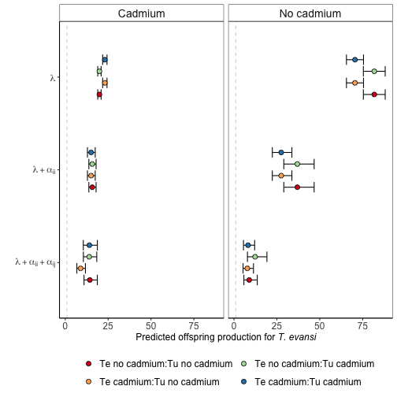

```r
## Plot ---------------------------

# This is for T. evansi
plotA<-ggplot(subset(pred_coex1Gen_long, parameter=="predTe_onlyLambda" |  parameter=="predTe_Lambda_INTRA" |  parameter=="predTe_ALL"), aes(y=parameter3, x=value))+
  facet_grid(.~Environment, labeller=labeller(Environment=Env))+
  geom_errorbarh(aes(xmin=value_L, xmax=value_U, group=interaction(Te, Tu)), colour="black", height=0.5, position=position_dodge2(0.5))+
  geom_point(aes(fill=interaction(Te, Tu)),size=2.5, position=position_dodge2(0.5), stat="identity", shape=21)+
  geom_vline(xintercept = 1, colour="lightgray", linetype="dashed")+
  theme_bw()+
  theme_plots+
  scale_fill_brewer(palette = "Spectral", labels=c("Te no cadmium:Tu no cadmium", "Te cadmium:Tu no cadmium", "Te no cadmium:Tu cadmium", "Te cadmium:Tu cadmium"), name="")+
  guides(fill=guide_legend(nrow=2))+
  xlab(expression(paste("Predicted offspring production for ", italic("T. evansi"))))+
  scale_y_discrete(labels=c(expression(lambda+ alpha[ii] + alpha [ij]),expression(lambda+ alpha[ii]), expression(lambda)), limits=rev(levels(droplevels(subset(pred_coex1Gen_long, parameter=="predTe_onlyLambda" |  parameter=="predTe_Lambda_INTRA" |  parameter=="predTe_ALL"))$parameter3)))+
  theme(legend.position = "bottom", axis.text = element_text(size=12), axis.title = element_text(face="plain", size=12))+
  ylab("")

plotA
```

```r
 save_plot("./Plots/Fig1A.pdf", width=17.5, height=10)
```

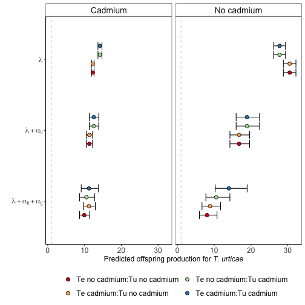

```r
# This is for T. urticae
plotB<-ggplot(subset(pred_coex1Gen_long, parameter=="predTu_onlyLambda" |  parameter=="predTu_Lambda_INTRA" |  parameter=="predTu_ALL"), aes(y=parameter3, x=value))+
  facet_grid(.~Environment, labeller=labeller(Environment=Env))+
  geom_errorbarh(aes(xmin=value_L, xmax=value_U, group=interaction(Te, Tu)), colour="black", height=0.5, position=position_dodge2(0.5))+
  geom_point(aes(fill=interaction(Te, Tu)),size=2.5, position=position_dodge2(0.5), stat="identity", shape=21)+
  geom_vline(xintercept = 1, colour="lightgray", linetype="dashed")+
  theme_bw()+
  theme_plots+
  scale_fill_brewer(palette = "Spectral", labels=c("Te no cadmium:Tu no cadmium", "Te cadmium:Tu no cadmium", "Te no cadmium:Tu cadmium", "Te cadmium:Tu cadmium"), name="")+
  xlab(expression(paste("Predicted offspring production for ", italic("T. urticae"))))+
  guides(fill=guide_legend(nrow=2))+
  scale_y_discrete(labels=c(expression(lambda+ alpha[ii] + alpha [ij]),expression(lambda+ alpha[ii]), expression(lambda)), limits=rev(levels(droplevels(subset(pred_coex1Gen_long, parameter=="predTu_onlyLambda" |  parameter=="predTu_Lambda_INTRA" |  parameter=="predTu_ALL"))$parameter3)))+
  theme(legend.position = "bottom", axis.text = element_text(size=12), axis.title = element_text(face="plain", size=12))+
  ylab("")

plotB
```

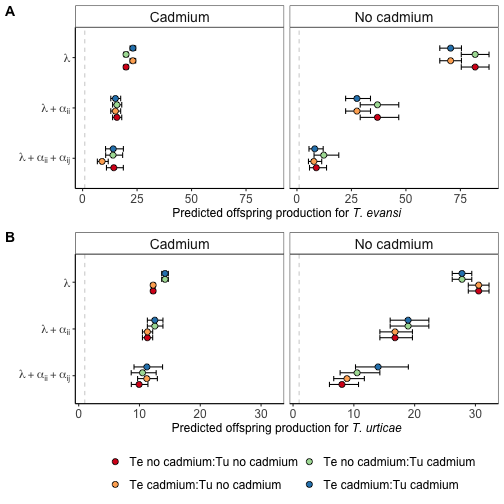

```r
save_plot("./Plots/Fig1B.pdf", width=17.5, height=10)


plot_grid((plotA+ theme(legend.position="none")), plotB, nrow=2, labels=c("A", "B"), rel_heights = c(0.45, 0.55))
```

```r
save_plot("./Plots/Fig1.pdf", width=20, height=20)

save_plot("./Plots/Fig1.png", width=20, height=20)
```

# Figure 2

### Importing parameters

```r
# Figure 2 ---------------------------
### Importing parameters -----
test_struct<-read.csv("./Analyses/structural_Pooled.csv")
# removing the first column
test_struct<-test_struct[,-1]
```

```r
## Set up data structure ---------------------------
# Since we are only focusing on positive growth rates, we transform all the negative slopes that would go to y <0 into 0 and all negative slopes that would go to x<0 into 90
test_struct[which(test_struct$a21_a11<0),"a21_a11"]<-0
test_struct[which(test_struct$a21_a11_lower<0),"a21_a11_lower"]<-0
test_struct[which(test_struct$a21_a11_upper<0),"a21_a11_upper"]<-0

test_struct[which(test_struct$a22_a12<0),"a22_a12"]<-90
test_struct[which(test_struct$a22_a12_lower<0),"a22_a12_lower"]<-90
test_struct[which(test_struct$a22_a12_upper<0),"a22_a12_upper"]<-90

#Since we will draw polygons with ggplot we need to have x and y coordinates for the 4 vertex

# This is just to guide the plotting. The values 0 and 3 correspond to the same point where the feasibility cone starts and ends. Then we have to calculate the coordinates for the middle
values_to_plot<-c(0,1, 2,3)
max_value<-8 # this value should be larger than the growth rate

  #All of the x start the same, but after calculating the y values, we will need to adjust the x so that the negative slopes in Tu are set to 0
# Creating a data frame to store the values
  CI_rep2<-as.data.frame(expand.grid(values=values_to_plot, Te_Regime=c("SR4", "SR5"), Tu_Regime=c("SR1", "SR2"), Environment=c("N", "Cd")))

  # Adding the x values corresponding to the coordinates for the mean, lower and upper intervals
CI_rep2$x<-mapvalues(CI_rep2$values, c(0,1,2,3), c(0,max_value,max_value,0))
CI_rep2$x_lower<-mapvalues(CI_rep2$values, c(0,1,2,3), c(0,max_value,max_value,0))
CI_rep2$x_upper<-mapvalues(CI_rep2$values, c(0,1,2,3), c(0,max_value,max_value,0))

# Loop to create the data frame where we calculate the vertex by multiplying the value of x by the slope (i.e. the edge of the feasibility domain)
aux_CI2<-as.data.frame(t(sapply(c(1:nrow(CI_rep2)), function(x){
  a<-subset(test_struct, Environment==CI_rep2$Environment[x] &
              Te_Regime==CI_rep2$Te_Regime[x] & Tu_Regime==CI_rep2$Tu_Regime[x])

  # If values are 0 or 3 then the points are always 0
  if(CI_rep2$values[x]==0 | CI_rep2$values[x]==3){
    b<-c(0,0,0)
    # If its 2 then we need to use the urticae edge
  }else if(CI_rep2$values[x]==2){
    vect<-c(a$a22_a12_lower[1],a$a22_a12[1],a$a22_a12_upper[1])
      # ordering to be sure that it matches (because facilitation switches values)
    vect<-vect[order(vect, decreasing=TRUE)]
    b<-c(CI_rep2$x_lower[x],CI_rep2$x[x], CI_rep2$x_upper[x])*vect
  }else if(CI_rep2$values[x]==1){ # If its 1 then we need to use the evansi edge
    vect<-c(a$a21_a11_lower[1],a$a21_a11[1],a$a21_a11_upper[1])
    # ordering to be sure that it matches (because facilitation switches values)
    vect<-vect[order(vect, decreasing=FALSE)]
    b<-c(CI_rep2$x_lower[x],CI_rep2$x[x], CI_rep2$x_upper[x])*vect
  }

  b
})))
# addin column names
colnames(aux_CI2)<-c("y_lower", "y", "y_upper")

#Joininig the data frame
CI_rep2<-as.data.frame(cbind(CI_rep2, aux_CI2))
```

#### no cadmium

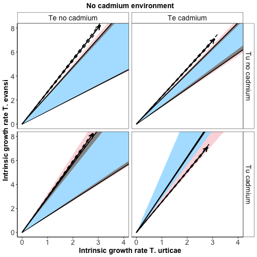

```r
## Plot ---------------------------
normal_feas<-ggplot(subset(test_struct, Environment=="N"), aes(x=Tu_lambda, y=Te_lambda, colour=interaction(Tu_Regime, Te_Regime)))+
  facet_grid(Tu_Regime~ Te_Regime, labeller=labeller(Tu_Regime=regimeTu, Te_Regime=regimeTe) )+
  geom_polygon(data=subset(CI_rep2,Environment=="N"),aes(x=x_upper, y=y_upper), fill="#FADADD",  linewidth=0.85, colour=NA)+
  geom_polygon(data=subset(CI_rep2,Environment=="N"),aes(x=x, y=y), fill="#969696",  linewidth=0.85, colour="black")+
  geom_polygon(data=subset(CI_rep2,Environment=="N"),aes(x=x_lower, y=y_lower), fill="lightskyblue1",  linewidth=0.85, colour=NA)+
  geom_polygon(data=subset(CI_rep2,Environment=="N" & Te_Regime=="SR5" & Tu_Regime=="SR2"),aes(x=x, y=y), fill="#969696", alpha=0.75, linewidth=0.85, colour="black")+
  geom_point(colour="black")+
  geom_segment(data=subset(test_struct, Environment=="N" ), aes(xend=Tu_lambda, yend=Te_lambda,x=0, y=0),  arrow=arrow(length = unit(0.3, "cm")), colour="black", linewidth=1)+
  geom_segment(data=subset(test_struct, Environment=="N" ), aes(xend=Tu_lambda_lower, yend=Te_lambda_lower,x=0, y=0),  colour="black", linetype="dashed", linewidth=0.75)+
  geom_segment(data=subset(test_struct, Environment=="N" ), aes(xend=Tu_lambda_upper, yend=Te_lambda_upper,x=0, y=0), colour="black", linetype="dashed", linewidth=0.75)+
  theme_bw()+
  theme_plots+
  ylab(c("Intrinsic growth rate T. evansi"))+
  xlab(c("Intrinsic growth rate T. urticae"))+
  theme(legend.position = "none",plot.title = element_text(hjust = 0.5))+
  ylim(c(-200,200))+
  xlim(c(-200,200))+
  coord_cartesian(xlim =c(0.01,4), ylim=c(0.01,8), expand = TRUE)+
  ggtitle("No cadmium environment")
normal_feas
```

```r
save_plot("./Plots/Fig2B_B.pdf", width=20, height=15)
```

#### cadmium

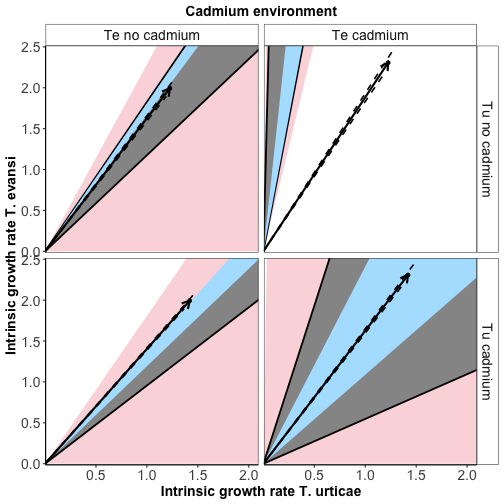

```r
cadmium_feas<-ggplot(subset(test_struct, Environment=="Cd"), aes(x=Tu_lambda, y=Te_lambda, colour=interaction(Tu_Regime, Te_Regime)))+
  facet_grid(Tu_Regime~ Te_Regime, labeller=labeller(Tu_Regime=regimeTu, Te_Regime=regimeTe) )+
  geom_polygon(data=subset(CI_rep2,Environment=="Cd"),aes(x=x_lower, y=y_lower), fill="#FADADD",linewidth=0.85, colour=NA)+
  geom_polygon(data=subset(CI_rep2,Environment=="Cd"),aes(x=x, y=y), fill="#969696", linewidth=0.85,colour="black")+
  geom_polygon(data=subset(CI_rep2,Environment=="Cd"),aes(x=x_upper, y=y_upper), fill="lightskyblue1",  linewidth=0.85, colour=NA)+
  geom_point(colour="black")+
  geom_segment(data=subset(test_struct, Environment=="Cd" ), aes(xend=Tu_lambda, yend=Te_lambda,x=0, y=0),  arrow=arrow(length = unit(0.3, "cm")), colour="black", linewidth=1)+
  geom_segment(data=subset(test_struct, Environment=="Cd" ), aes(xend=Tu_lambda_lower, yend=Te_lambda_lower,x=0, y=0),  colour="black", linetype="dashed", linewidth=0.75)+
  geom_segment(data=subset(test_struct, Environment=="Cd" ), aes(xend=Tu_lambda_upper, yend=Te_lambda_upper,x=0, y=0), colour="black", linetype="dashed", linewidth=0.75)+
  theme_bw()+
  theme_plots+
  ylab(c("Intrinsic growth rate T. evansi"))+
  xlab(c("Intrinsic growth rate T. urticae"))+
  theme(legend.position = "none",plot.title = element_text(hjust = 0.5))+
  #ylim(c(0,8))+
  #xlim(c(0,5))+
  coord_cartesian(xlim =c(0.1,2), ylim=c(0.1,2.4), expand = TRUE)+
  ggtitle("Cadmium environment")

cadmium_feas
```

```r
save_plot("./Plots/Fig2A_B.pdf", width=20, height=15)
```

#### both together

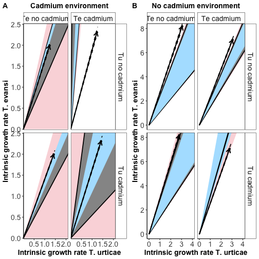

```r
# joining the two plots
plot_grid(cadmium_feas, normal_feas, ncol=2, labels=c("A", "B") )
```

```r
# save plots
save_plot("./Plots/Fig2.pdf", width=30, height=15)
save_plot("./Plots/Fig2.tiff", width=30, height=15)
```

# Figure 3

### Importing parameters

```r
# Figure 3 ---------------------------
struct_mat_REP_final2<-read.csv("./Analyses/min_distance_pooled.csv", header=TRUE)
struct_mat_w0_final<-read.csv("./Analyses/min_distance_per_replicate.csv", header=TRUE)
```

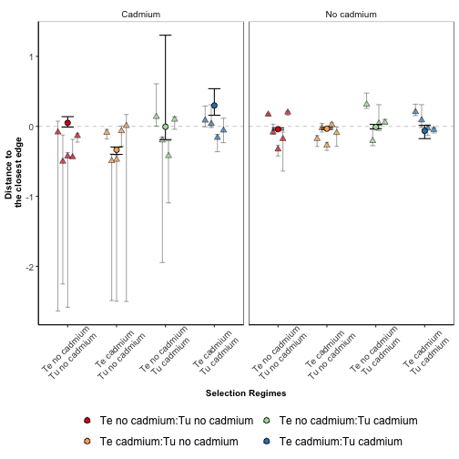

```r
## Plot ---------------------------
ggplot(struct_mat_w0_final, aes(x=interaction(Te_Regime, Tu_Regime), y=minDistance, fill=interaction(Te_Regime, Tu_Regime)))+
  facet_grid(.~Environment, labeller=labeller(Environment=Env))+
  geom_hline(yintercept = 0, colour="lightgrey", linetype="dashed")+
  geom_errorbar(data=struct_mat_w0_final, aes(ymin=minDistance_L, ymax=minDistance_U), alpha=0.35, position=position_dodge2(0.5), width=0.5)+
  geom_point(size=2, shape=24,position=position_dodge2(0.5), alpha=0.65)+
  geom_errorbar(data=struct_mat_REP_final2, aes(ymin=minDistance_L, ymax=minDistance_U), width=0.25)+
  geom_point(data=struct_mat_REP_final2,aes(x=interaction(Te_Regime, Tu_Regime), y=minDistance, fill=interaction(Te_Regime, Tu_Regime)), colour="black", size=2.5, shape=21 )+
  theme_bw()+
  theme_plots+
  scale_x_discrete(labels=c("Te no cadmium\nTu no cadmium","Te cadmium\nTu no cadmium","Te no cadmium\nTu cadmium","Te cadmium\nTu cadmium"))+
  #scale_color_manual(values=c("darkred", "darkblue"), labels=c("Cadmium", "Water"))+
  ylab("Distance to \n the closest edge")+
  scale_fill_brewer(palette = "Spectral", labels=c("Te no cadmium:Tu no cadmium", "Te cadmium:Tu no cadmium", "Te no cadmium:Tu cadmium", "Te cadmium:Tu cadmium"), name="")+
  xlab(expression(paste("Predicted offspring production for ", italic("T. urticae"))))+
  guides(fill=guide_legend(nrow=2))+
  xlab("Selection Regimes")+
  theme(legend.position = "bottom", strip.background =element_rect(colour="white"), panel.border = element_rect(colour="black"), axis.text.x = element_text(size=10, angle = 45, vjust = 0.63), axis.title = element_text(size=10, face="bold"), strip.text = element_text(size=10), axis.text.y = element_text(size=10))
```

```r
save_plot("./Plots/Fig3.pdf", width=15, height=10)
save_plot("./Plots/Fig3.png", width=15, height=10)
```

# Figure 4

### Importing data

```r
# Figure 4 ---------------------------

## Importing data ------
sum_observed_coex_rep<-read.csv(file="./Analyses/popDyn_pooledData.csv", header=TRUE)

sum_observed_coex_ALL2<-read.csv(file="./Analyses/popDyn_replicates.csv", header=TRUE)
```

### slopes and figure

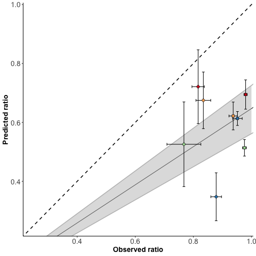

```r
## Slopes ---------------------------
# This is from the summary of the model so we can put the correct slope and CI in the plot, and not ggplot's model
slope_all<-log(1.91) #slope m7 obtained from emmeans
slope_ci_L<-log(1.91 - 0.156)
slope_ci_U<-log(1.91 + 0.156)

# Predicting the data for the slope
slopes_data<-data.frame(x=seq(0,1, 0.05))
slopes_data$ymin<-slope_ci_L*slopes_data$x
slopes_data$ymax<-slope_ci_U*slopes_data$x

## Plot ---------------------------
ggplot(sum_observed_coex_ALL2)+
  geom_abline(intercept=0, slope=1, color="black", linewidth=0.75, linetype="dashed")+
  geom_abline(intercept = 0, slope=slope_all)+
  geom_abline(intercept = 0, slope=slope_ci_L, colour="grey",linewidth=0.75)+
  geom_abline(intercept = 0, slope=slope_ci_U,  colour="grey",linewidth=0.75)+
  geom_ribbon(data=slopes_data, aes(ymin=ymin,ymax=ymax, x=x), fill="grey", alpha=0.5) +
  geom_errorbar(data=sum_observed_coex_ALL2,aes(x=meanRatio,y=mean_pred,ymin=mean_pred-sdPred, ymax=mean_pred+sdPred), width=0.009, colour="black")+
  geom_errorbarh(data=sum_observed_coex_ALL2,aes(y=mean_pred, xmin=meanRatio-sdRatio, xmax=meanRatio+sdRatio), height=0.009, colour="black")+
  geom_point(size=2.3, aes(x=meanRatio,y=mean_pred,fill=interaction(SRTu, SRTe), shape=Env))+
  scale_fill_manual(values=c("#D7191C", "#FDAE61" ,"#ABDDA4", "#2B83BA"), labels=c("Te no cadmium:Tu no cadmium", "Te cadmium: Tu no cadmium", "Te no cadmium: Tu cadmium", "Te cadmium: Tu cadmium"))+
  scale_shape_manual(values=c(22,23))+
  theme_plots+
  xlab("Observed ratio")+
  ylab("Predicted ratio")+
  ylim(c(-0.1,1.2))+
  xlim(c(0,1.2))+
  theme(legend.position = "none")+
  coord_cartesian(xlim=c(0.25,0.97), ylim=c(0.25, 0.97))
```

```r
save_plot("./Plots/Fig4.pdf", width=15, height=15)

save_plot("./Plots/Fig4.png", width=20, height=20)
```

```r
# Supplementary figures-------
```

```r
## Figures S3 - S8
```

```r
# Figure S3 to S8 ------
```

### Importing data

Importing the data to get the parameter estimates for pooled data

```r
### Importing data---------------------------
param_all_REP<-read.csv("./Analyses/cxr_normal_Pooled/parameters_cxr_normal_Pooled.csv")
param_all_REP_upper<-read.csv("./Analyses/cxr_normal_Pooled/parameters_cxr_normal_Pooled_upper.csv")
param_all_REP_lower<-read.csv( "./Analyses/cxr_normal_Pooled/parameters_cxr_normal_Pooled_lower.csv")
param_all_REP<-param_all_REP[,-1]
param_all_REP_upper<-param_all_REP_upper[,-1]
param_all_REP_lower<-param_all_REP_lower[,-1]
```

Importing the data to get the parameter estimates for each replicate

```r
param_all_w0<-read.csv("./Analyses/cxr_normal_Replicates/parameters_cxr_normal.csv")
param_all_w0_upper<-read.csv("./Analyses/cxr_normal_Replicates/parameters_cxr_normal_upper.csv")
param_all_w0_lower<-read.csv( "./Analyses/cxr_normal_Replicates/parameters_cxr_normal_lower.csv")

param_all_w0<-param_all_w0[,-1]
param_all_w0_upper<-param_all_w0_upper[,-1]
param_all_w0_lower<-param_all_w0_lower[,-1]
```

### Data wrangling pooled data

```r
### Data wrangling ---------------------------
param_all_REP_long<-gather(param_all_REP, parameter, value,Tu_lambda:Te_inter )

param_all_REP_long$category<-mapvalues(param_all_REP_long$parameter, c("Tu_lambda", "Te_lambda", "Tu_intra", "Te_intra","Tu_inter", "Te_inter"), c("lambda", "lambda", "intra", "intra", "inter", "inter"))

param_all_REP_lower_long<-gather(param_all_REP_lower, parameter, value,Tu_lambda:Te_inter )

param_all_REP_lower_long$category<-mapvalues(param_all_REP_lower_long$parameter, c("Tu_lambda", "Te_lambda", "Tu_intra", "Te_intra","Tu_inter", "Te_inter"), c("lambda", "lambda", "intra", "intra", "inter", "inter"))

param_all_REP_upper_long<-gather(param_all_REP_upper, parameter, value,Tu_lambda:Te_inter )

param_all_REP_upper_long$category<-mapvalues(param_all_REP_upper_long$parameter, c("Tu_lambda", "Te_lambda", "Tu_intra", "Te_intra","Tu_inter", "Te_inter"), c("lambda", "lambda", "intra", "intra", "inter", "inter"))

colnames(param_all_REP_lower_long)[5]<-"lower"
colnames(param_all_REP_upper_long)[5]<-"upper"

str(param_all_REP_long)
```

```
## 'data.frame':	48 obs. of  6 variables:
##  $ Tu_Regime  : chr  "SR1" "SR2" "SR1" "SR2" ...
##  $ Te_Regime  : chr  "SR4" "SR4" "SR5" "SR5" ...
##  $ Environment: chr  "N" "N" "N" "N" ...
##  $ parameter  : chr  "Tu_lambda" "Tu_lambda" "Tu_lambda" "Tu_lambda" ...
##  $ value      : num  3.05 2.78 3.05 2.78 1.22 ...
##  $ category   : chr  "lambda" "lambda" "lambda" "lambda" ...
```

```r
param_all_REP_long<-cbind(param_all_REP_long[,1:6],param_all_REP_lower_long$lower, param_all_REP_upper_long$upper)

colnames(param_all_REP_long)[7:8]<-c("lower","upper")
```

### Data wrangling replicate data

```r
param_all_w0_long<-gather(param_all_w0, parameter, value,Tu_lambda:Te_inter )

param_all_w0_long$category<-mapvalues(param_all_w0_long$parameter, c("Tu_lambda", "Te_lambda", "Tu_intra", "Te_intra","Tu_inter", "Te_inter"), c("lambda", "lambda", "intra", "intra", "inter", "inter"))

param_all_w0_lower_long<-gather(param_all_w0_lower, parameter, value,Tu_lambda:Te_inter )

param_all_w0_lower_long$category<-mapvalues(param_all_w0_lower_long$parameter, c("Tu_lambda", "Te_lambda", "Tu_intra", "Te_intra","Tu_inter", "Te_inter"), c("lambda", "lambda", "intra", "intra", "inter", "inter"))

param_all_w0_upper_long<-gather(param_all_w0_upper, parameter, value,Tu_lambda:Te_inter )

param_all_w0_upper_long$category<-mapvalues(param_all_w0_upper_long$parameter, c("Tu_lambda", "Te_lambda", "Tu_intra", "Te_intra","Tu_inter", "Te_inter"), c("lambda", "lambda", "intra", "intra", "inter", "inter"))

colnames(param_all_w0_lower_long)[6]<-"lower"
colnames(param_all_w0_upper_long)[6]<-"upper"

str(param_all_w0_long)
```

```
## 'data.frame':	216 obs. of  7 variables:
##  $ Tu_Regime  : chr  "SR1" "SR2" "SR1" "SR2" ...
##  $ Te_Regime  : chr  "SR4" "SR4" "SR5" "SR5" ...
##  $ Replicate  : int  1 1 1 1 2 2 3 3 3 3 ...
##  $ Environment: chr  "N" "N" "N" "N" ...
##  $ parameter  : chr  "Tu_lambda" "Tu_lambda" "Tu_lambda" "Tu_lambda" ...
##  $ value      : num  2.91 2.48 2.91 2.48 2.84 ...
##  $ category   : chr  "lambda" "lambda" "lambda" "lambda" ...
```

```r
param_all_w0_long<-cbind(param_all_w0_long[,1:6],param_all_w0_lower_long$lower, param_all_w0_upper_long$upper)

colnames(param_all_w0_long)[7:8]<-c("lower","upper")
str(param_all_w0_long)
```

```
## 'data.frame':	216 obs. of  8 variables:
##  $ Tu_Regime  : chr  "SR1" "SR2" "SR1" "SR2" ...
##  $ Te_Regime  : chr  "SR4" "SR4" "SR5" "SR5" ...
##  $ Replicate  : int  1 1 1 1 2 2 3 3 3 3 ...
##  $ Environment: chr  "N" "N" "N" "N" ...
##  $ parameter  : chr  "Tu_lambda" "Tu_lambda" "Tu_lambda" "Tu_lambda" ...
##  $ value      : num  2.91 2.48 2.91 2.48 2.84 ...
##  $ lower      : num  2.56 2.21 2.56 2.21 2.52 ...
##  $ upper      : num  3.26 2.74 3.26 2.74 3.16 ...
```

## Cadmium env

```r
### Cadmium environment ---------------------------
```

#### Growth rate

```r
### Tu
Tu_gr_ev<-ggplot(data=subset(param_all_REP_long, (parameter=="Tu_lambda" & Te_Regime=="SR4" & Environment=="Cd")), aes(fill=Tu_Regime, y=value, x=Tu_Regime))+
  geom_hline(yintercept = 1, colour="lightgray", linetype="dashed")+
  geom_errorbar(data=subset(param_all_w0_long, (parameter=="Tu_lambda" & Te_Regime=="SR4" & Environment=="Cd")), aes(y=value, x=Tu_Regime, ymin=lower, ymax=upper), position=position_dodge2(width=0.3), colour="grey", width=0.3)+
  geom_point(data=subset(param_all_w0_long, (parameter=="Tu_lambda" & Te_Regime=="SR4" & Environment=="Cd")), position=position_dodge2(width=0.3), size=2, shape=24,aes(fill=Tu_Regime, y=value, x=Tu_Regime), alpha=0.85, colour="darkgrey")+
  geom_errorbar(data=subset(param_all_REP_long, (parameter=="Tu_lambda" & Te_Regime=="SR4" & Environment=="Cd")), aes(ymin=lower, ymax=upper), colour="black", width=0.1)+
  geom_point(data=subset(param_all_REP_long, (parameter=="Tu_lambda" & Te_Regime=="SR4" & Environment=="Cd")), size=4, shape=21)+
  theme_plots+
  scale_x_discrete(labels=c("No cadmium","Cadmium"))+
  scale_fill_manual(values=c("lightgrey", "black"), labels=c("No cadmium", "Cadmium"), name="")+
  ylab("Intrinsic growth rate\n(T. urticae)")+
  xlab("T. urticae selection regime")+theme(legend.position = "None")

## Te
Te_gr_ev<-ggplot(data=subset(param_all_REP_long, (parameter=="Te_lambda" & Tu_Regime=="SR1" & Environment=="Cd")), aes(fill=Te_Regime, y=value, x=Te_Regime))+
  geom_hline(yintercept = 1, colour="lightgray", linetype="dashed")+
  geom_errorbar(data=subset(param_all_w0_long, (parameter=="Te_lambda" & Tu_Regime=="SR1" & Environment=="Cd")), aes(y=value, x=Te_Regime, ymin=lower, ymax=upper), position=position_dodge2(width=0.3), colour="grey", width=0.3)+
  geom_point(data=subset(param_all_w0_long, (parameter=="Te_lambda" & Tu_Regime=="SR1" & Environment=="Cd")), position=position_dodge2(width=0.3), size=2, shape=24,aes(fill=Te_Regime, y=value, x=Te_Regime), alpha=0.85, colour="darkgrey")+
  geom_errorbar(data=subset(param_all_REP_long, (parameter=="Te_lambda" & Tu_Regime=="SR1" & Environment=="Cd")), aes(ymin=lower, ymax=upper), colour="black", width=0.1)+
  geom_point(data=subset(param_all_REP_long, (parameter=="Te_lambda" & Tu_Regime=="SR1" & Environment=="Cd")), size=4, shape=21)+
  theme_plots+
  scale_x_discrete(labels=c("No cadmium","Cadmium"))+
  scale_fill_manual(values=c("lightgrey", "black"), labels=c("No cadmium", "Cadmium"), name="")+
  ylab("Intrinsic growth rate\n(T. evansi)")+
  xlab("T. evansi selection regime")+ theme(legend.position = "None")
```

#### Intraspecific

```r
### Tu
Tu_intra_ev<-ggplot(data=subset(param_all_REP_long, (parameter=="Tu_intra" & Te_Regime=="SR4" & Environment=="Cd")), aes(fill=Tu_Regime, y=value, x=Tu_Regime))+
  geom_hline(yintercept = 0, colour="lightgray", linetype="dashed")+
  geom_errorbar(data=subset(param_all_w0_long, (parameter=="Tu_intra" & Te_Regime=="SR4" & Environment=="Cd")), aes(y=value, x=Tu_Regime, ymin=lower, ymax=upper), position=position_dodge2(width=0.3), colour="grey", width=0.3)+
  geom_point(data=subset(param_all_w0_long, (parameter=="Tu_intra" & Te_Regime=="SR4" & Environment=="Cd")), position=position_dodge2(width=0.3), size=2, shape=24,aes(fill=Tu_Regime, y=value, x=Tu_Regime), alpha=0.85, colour="darkgrey")+
  geom_errorbar(data=subset(param_all_REP_long, (parameter=="Tu_intra" & Te_Regime=="SR4" & Environment=="Cd")), aes(ymin=lower, ymax=upper), colour="black", width=0.1)+
  geom_point(data=subset(param_all_REP_long, (parameter=="Tu_intra" & Te_Regime=="SR4" & Environment=="Cd")), size=4, shape=21)+
  theme_plots+
  scale_x_discrete(labels=c("No cadmium","Cadmium"))+
  scale_fill_manual(values=c("lightgrey", "black"), labels=c("No cadmium", "Cadmium"), name="")+
  ylab("Strength of intraspecific\ncompetition (T. urticae)")+
  xlab("T. urticae selection regime")+theme(legend.position = "None")+
  ylim(c(-0.05,0.15))

### Te
Te_intra_ev<-ggplot(data=subset(param_all_REP_long, (parameter=="Te_intra" & Tu_Regime=="SR1" & Environment=="Cd")), aes(fill=Te_Regime, y=value, x=Te_Regime))+
  geom_hline(yintercept = 0, colour="lightgray", linetype="dashed")+
  geom_errorbar(data=subset(param_all_w0_long, (parameter=="Te_intra" & Tu_Regime=="SR1" & Environment=="Cd")), aes(y=value, x=Te_Regime, ymin=lower, ymax=upper), position=position_dodge2(width=0.3), colour="grey", width=0.3)+
  geom_point(data=subset(param_all_w0_long, (parameter=="Te_intra" & Tu_Regime=="SR1" & Environment=="Cd")), position=position_dodge2(width=0.3), size=2, shape=24,aes(fill=Te_Regime, y=value, x=Te_Regime), alpha=0.85, colour="darkgrey")+
  geom_errorbar(data=subset(param_all_REP_long, (parameter=="Te_intra" & Tu_Regime=="SR1" & Environment=="Cd")), aes(ymin=lower, ymax=upper), colour="black", width=0.1)+
  geom_point(data=subset(param_all_REP_long, (parameter=="Te_intra" & Tu_Regime=="SR1" & Environment=="Cd")), size=4, shape=21)+
  theme_plots+
  scale_x_discrete(labels=c("No cadmium","Cadmium"))+
  scale_fill_manual(values=c("lightgrey", "black"), labels=c("No cadmium", "Cadmium"), name="")+
  ylab("Strength of intraspecific\ncompetition (T. evansi)")+
  xlab("T. evansi selection regime")+theme(legend.position = "None")+
  ylim(c(-0.05,0.15))
```

#### Interspecific

```r
Tu_inter_ev<-ggplot(data=subset(param_all_REP_long, (parameter=="Tu_inter" & Environment=="Cd")), aes(fill=interaction(Te_Regime,Tu_Regime), y=value, x=Tu_Regime))+
  geom_hline(yintercept = 0, colour="lightgray", linetype="dashed")+
  geom_errorbar(data=subset(param_all_w0_long, (parameter=="Tu_inter" & Environment=="Cd")), aes(y=value, x=Tu_Regime, ymin=lower, ymax=upper), position=position_dodge2(width=0.3), colour="grey", width=0.3)+
  geom_point(data=subset(param_all_w0_long, (parameter=="Tu_inter"  & Environment=="Cd")), position=position_dodge2(width=0.3), size=2, shape=24,aes(fill=interaction(Te_Regime,Tu_Regime), y=value, x=Tu_Regime), alpha=0.85, colour="darkgrey")+
  geom_errorbar(data=subset(param_all_REP_long, (parameter=="Tu_inter" & Environment=="Cd")), aes(ymin=lower, ymax=upper),position=position_dodge2(0.3), colour="black", width=0.3)+
  geom_point(data=subset(param_all_REP_long, (parameter=="Tu_inter" & Environment=="Cd")),position=position_dodge2(0.3), size=4, shape=21)+
  theme_plots+
  scale_x_discrete(labels=c("No cadmium","Cadmium"))+
  scale_fill_manual(values=c("#D7191C", "#FDAE61" ,"#ABDDA4", "#2B83BA"), labels=c("Te no cadmium:Tu no cadmium", "Te cadmium: Tu no cadmium", "Te no cadmium: Tu cadmium", "Te cadmium: Tu cadmium"), name="")+
  ylab("Strength of interspecific\ncompetition (T. urticae)")+
  xlab("T. urticae selection regime")+
  guides(fill=guide_legend(nrow = 4))+
  theme(legend.position = "None", legend.text = element_text(size=10), legend.background = element_rect(fill=NA), legend.key.size = unit(0.2, 'cm'))+
  ylim(c(-0.15,0.2))

### Te
Te_inter_ev<-ggplot(data=subset(param_all_REP_long, (parameter=="Te_inter" & Environment=="Cd")), aes(fill=interaction(Te_Regime,Tu_Regime), y=value, x=Te_Regime))+
  geom_hline(yintercept = 0, colour="lightgray", linetype="dashed")+
  geom_errorbar(data=subset(param_all_w0_long, (parameter=="Te_inter" & Environment=="Cd")), aes(y=value, x=Te_Regime, ymin=lower, ymax=upper), position=position_dodge2(width=0.3), colour="grey", width=0.3)+
  geom_point(data=subset(param_all_w0_long, (parameter=="Te_inter"  & Environment=="Cd")), position=position_dodge2(width=0.3), size=2, shape=24,aes(fill=interaction(Te_Regime,Tu_Regime), y=value, x=Te_Regime), alpha=0.85, colour="darkgrey")+
  geom_errorbar(data=subset(param_all_REP_long, (parameter=="Te_inter" & Environment=="Cd")), aes(ymin=lower, ymax=upper),position=position_dodge2(0.3), colour="black", width=0.3)+
  geom_point(data=subset(param_all_REP_long, (parameter=="Te_inter" & Environment=="Cd")),position=position_dodge2(0.3), size=4, shape=21)+
  theme_plots+
  scale_x_discrete(labels=c("No cadmium","Cadmium"))+
  scale_fill_manual(values=c("#D7191C", "#FDAE61" ,"#ABDDA4", "#2B83BA"), labels=c("Te no cadmium:Tu no cadmium", "Te cadmium: Tu no cadmium", "Te no cadmium: Tu cadmium", "Te cadmium: Tu cadmium"), name="")+
  guides(fill=guide_legend(nrow = 4))+
  theme(legend.position = "None", legend.text = element_text(size=10), legend.background = element_rect(fill=NA), legend.key.size = unit(0.2, 'cm'))+
  ylab("Strength of interspecific\ncompetition (T. evansi)")+
  xlab("T. evansi selection regime")+
  ylim(c(-0.15,0.2))
```

### Plotting

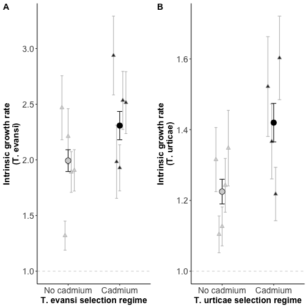

```r
## Plot---------------------------
plot_grid(Te_gr_ev, Tu_gr_ev, labels=c("A", "B"))
```

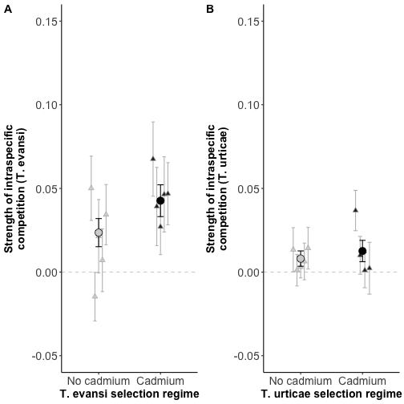

```r
save_plot("./Plots/FigS7.pdf", width=30, height=15)
save_plot("./Plots/FigS7.png", width=30, height=15)

plot_grid(Te_intra_ev, Tu_intra_ev, labels=c("A", "B"))
```

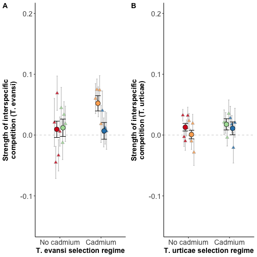

```r
save_plot("./Plots/FigS3.pdf", width=30, height=15)
save_plot("./Plots/FigS3.png", width=30, height=15)

plot_grid(Te_inter_ev, Tu_inter_ev, labels=c("A", "B"))
```

```r
save_plot("./Plots/FigS4.pdf", width=30, height=15)
save_plot("./Plots/FigS4.png", width=30, height=15)
```

## Ancestral env

```r
### No cadmium environment ---------------------------
```

#### Growth rate

```r
#Tu
Tu_gr_ev_N<-ggplot(data=subset(param_all_REP_long, (parameter=="Tu_lambda" & Te_Regime=="SR4" & Environment=="N")), aes(fill=Tu_Regime, y=value, x=Tu_Regime))+
  geom_hline(yintercept = 1, colour="lightgray", linetype="dashed")+
  geom_errorbar(data=subset(param_all_w0_long, (parameter=="Tu_lambda" & Te_Regime=="SR4" & Environment=="N")), aes(y=value, x=Tu_Regime, ymin=lower, ymax=upper), position=position_dodge2(width=0.3), colour="grey", width=0.3)+
  geom_point(data=subset(param_all_w0_long, (parameter=="Tu_lambda" & Te_Regime=="SR4" & Environment=="N")), position=position_dodge2(width=0.3), size=2, shape=24,aes(fill=Tu_Regime, y=value, x=Tu_Regime), alpha=0.85, colour="darkgrey")+
  geom_errorbar(data=subset(param_all_REP_long, (parameter=="Tu_lambda" & Te_Regime=="SR4" & Environment=="N")), aes(ymin=lower, ymax=upper), colour="black", width=0.1)+
  geom_point(data=subset(param_all_REP_long, (parameter=="Tu_lambda" & Te_Regime=="SR4" & Environment=="N")), size=4, shape=21)+
  theme_plots+
  scale_x_discrete(labels=c("No cadmium","Cadmium"))+
  scale_fill_manual(values=c("lightgrey", "black"), labels=c("No cadmium", "Cadmium"), name="")+
  ylab("Intrinsic growth rate\n(T. urticae)")+
  xlab("T. urticae selection regime")+theme(legend.position = "None")+
  ylim(c(0,17))

# Te

Te_gr_ev_N<-ggplot(data=subset(param_all_REP_long, (parameter=="Te_lambda" & Tu_Regime=="SR1" & Environment=="N")), aes(fill=Te_Regime, y=value, x=Te_Regime))+
  geom_hline(yintercept = 1, colour="lightgray", linetype="dashed")+
  geom_errorbar(data=subset(param_all_w0_long, (parameter=="Te_lambda" & Tu_Regime=="SR1" & Environment=="N")), aes(y=value, x=Te_Regime, ymin=lower, ymax=upper), position=position_dodge2(width=0.3), colour="grey", width=0.3)+
  geom_point(data=subset(param_all_w0_long, (parameter=="Te_lambda" & Tu_Regime=="SR1" & Environment=="N")), position=position_dodge2(width=0.3), size=2, shape=24,aes(fill=Te_Regime, y=value, x=Te_Regime), alpha=0.85, colour="darkgrey")+
  geom_errorbar(data=subset(param_all_REP_long, (parameter=="Te_lambda" & Tu_Regime=="SR1" & Environment=="N")), aes(ymin=lower, ymax=upper), colour="black", width=0.1)+
  geom_point(data=subset(param_all_REP_long, (parameter=="Te_lambda" & Tu_Regime=="SR1" & Environment=="N")), size=4, shape=21)+
  theme_plots+
  scale_x_discrete(labels=c("No cadmium","Cadmium"))+
  scale_fill_manual(values=c("lightgrey", "black"), labels=c("No cadmium", "Cadmium"), name="")+
  ylab("Intrinsic growth rate\n(T. evansi)")+
  xlab("T. evansi selection regime")+ theme(legend.position = "None")+
  ylim(c(0,17))
```

#### Intraspecific competition

```r
#Tu
Tu_intra_ev_N<-ggplot(data=subset(param_all_REP_long, (parameter=="Tu_intra" & Te_Regime=="SR4" & Environment=="N")), aes(fill=Tu_Regime, y=value, x=Tu_Regime))+
  geom_hline(yintercept = 0, colour="lightgray", linetype="dashed")+
  geom_errorbar(data=subset(param_all_w0_long, (parameter=="Tu_intra" & Te_Regime=="SR4" & Environment=="N")), aes(y=value, x=Tu_Regime, ymin=lower, ymax=upper), position=position_dodge2(width=0.3), colour="grey", width=0.3)+
  geom_point(data=subset(param_all_w0_long, (parameter=="Tu_intra" & Te_Regime=="SR4" & Environment=="N")), position=position_dodge2(width=0.3), size=2, shape=24,aes(fill=Tu_Regime, y=value, x=Tu_Regime), alpha=0.85, colour="darkgrey")+
  geom_errorbar(data=subset(param_all_REP_long, (parameter=="Tu_intra" & Te_Regime=="SR4" & Environment=="N")), aes(ymin=lower, ymax=upper), colour="black", width=0.1)+
  geom_point(data=subset(param_all_REP_long, (parameter=="Tu_intra" & Te_Regime=="SR4" & Environment=="N")), size=4, shape=21)+
  theme_plots+
  scale_x_discrete(labels=c("No cadmium","Cadmium"))+
  scale_fill_manual(values=c("lightgrey", "black"), labels=c("No cadmium", "Cadmium"), name="")+
  ylab("Strength of intraspecific\ncompetition (T. urticae)")+
  xlab("T. urticae selection regime")+theme(legend.position = "None")+
  ylim(c(-0.01,0.16))

# Te
Te_intra_ev_N<-ggplot(data=subset(param_all_REP_long, (parameter=="Te_intra" & Tu_Regime=="SR1" & Environment=="N")), aes(fill=Te_Regime, y=value, x=Te_Regime))+
  geom_hline(yintercept = 0, colour="lightgray", linetype="dashed")+
  geom_errorbar(data=subset(param_all_w0_long, (parameter=="Te_intra" & Tu_Regime=="SR1" & Environment=="N")), aes(y=value, x=Te_Regime, ymin=lower, ymax=upper), position=position_dodge2(width=0.3), colour="grey", width=0.3)+
  geom_point(data=subset(param_all_w0_long, (parameter=="Te_intra" & Tu_Regime=="SR1" & Environment=="N")), position=position_dodge2(width=0.3), size=2, shape=24,aes(fill=Te_Regime, y=value, x=Te_Regime), alpha=0.85, colour="darkgrey")+
  geom_errorbar(data=subset(param_all_REP_long, (parameter=="Te_intra" & Tu_Regime=="SR1" & Environment=="N")), aes(ymin=lower, ymax=upper), colour="black", width=0.1)+
  geom_point(data=subset(param_all_REP_long, (parameter=="Te_intra" & Tu_Regime=="SR1" & Environment=="N")), size=4, shape=21)+
  theme_plots+
  scale_x_discrete(labels=c("No cadmium","Cadmium"))+
  scale_fill_manual(values=c("lightgrey", "black"), labels=c("No cadmium", "Cadmium"), name="")+
  ylab("Strength of intraspecific\ncompetition (T. evansi)")+
  xlab("T. evansi selection regime")+theme(legend.position = "None")+
  ylim(c(-0.01,0.16))
```

#### Interspecific competition

```r
# Tu
Tu_inter_ev_N<-ggplot(data=subset(param_all_REP_long, (parameter=="Tu_inter" & Environment=="N")), aes(fill=interaction(Te_Regime,Tu_Regime), y=value, x=Tu_Regime))+
  geom_hline(yintercept = 0, colour="lightgray", linetype="dashed")+
  geom_errorbar(data=subset(param_all_w0_long, (parameter=="Tu_inter" & Environment=="N")), aes(y=value, x=Tu_Regime, ymin=lower, ymax=upper), position=position_dodge2(width=0.3), colour="grey", width=0.3)+
  geom_point(data=subset(param_all_w0_long, (parameter=="Tu_inter"  & Environment=="N")), position=position_dodge2(width=0.3), size=2, shape=24,aes(fill=interaction(Te_Regime,Tu_Regime), y=value, x=Tu_Regime), alpha=0.85, colour="darkgrey")+
  geom_errorbar(data=subset(param_all_REP_long, (parameter=="Tu_inter" & Environment=="N")), aes(ymin=lower, ymax=upper),position=position_dodge2(0.3), colour="black", width=0.3)+
  geom_point(data=subset(param_all_REP_long, (parameter=="Tu_inter" & Environment=="N")),position=position_dodge2(0.3), size=4, shape=21)+
  theme_plots+
  scale_x_discrete(labels=c("No cadmium","Cadmium"))+
  scale_fill_manual(values=c("#D7191C", "#FDAE61" ,"#ABDDA4", "#2B83BA"), labels=c("Te no cadmium:Tu no cadmium", "Te cadmium: Tu no cadmium", "Te no cadmium: Tu cadmium", "Te cadmium: Tu cadmium"), name="")+
  ylab("Strength of interspecific\ncompetition (T. urticae)")+
  xlab("T. urticae selection regime")+
  guides(fill=guide_legend(nrow = 4))+
  theme(legend.position = "None", legend.text = element_text(size=10), legend.background = element_rect(fill=NA), legend.key.size = unit(0.2, 'cm'))+
  ylim(c(-0.05,0.25))

# Te
Te_inter_ev_N<-ggplot(data=subset(param_all_REP_long, (parameter=="Te_inter" & Environment=="N")), aes(fill=interaction(Te_Regime,Tu_Regime), y=value, x=Te_Regime))+
  geom_hline(yintercept = 0, colour="lightgray", linetype="dashed")+
  geom_errorbar(data=subset(param_all_w0_long, (parameter=="Te_inter" & Environment=="N")), aes(y=value, x=Te_Regime, ymin=lower, ymax=upper), position=position_dodge2(width=0.3), colour="grey", width=0.3)+
  geom_point(data=subset(param_all_w0_long, (parameter=="Te_inter"  & Environment=="N")), position=position_dodge2(width=0.3), size=2, shape=24,aes(fill=interaction(Te_Regime,Tu_Regime), y=value, x=Te_Regime), alpha=0.85, colour="darkgrey")+
  geom_errorbar(data=subset(param_all_REP_long, (parameter=="Te_inter" & Environment=="N")), aes(ymin=lower, ymax=upper),position=position_dodge2(0.3), colour="black", width=0.3)+
  geom_point(data=subset(param_all_REP_long, (parameter=="Te_inter" & Environment=="N")),position=position_dodge2(0.3), size=4, shape=21)+
  theme_plots+
  scale_x_discrete(labels=c("No cadmium","Cadmium"))+
  scale_fill_manual(values=c("#D7191C", "#FDAE61" ,"#ABDDA4", "#2B83BA"), labels=c("Te no cadmium:Tu no cadmium", "Te cadmium: Tu no cadmium", "Te no cadmium: Tu cadmium", "Te cadmium: Tu cadmium"), name="")+
  guides(fill=guide_legend(nrow = 4))+
  theme(legend.position = "None", legend.text = element_text(size=10), legend.background = element_rect(fill=NA), legend.key.size = unit(0.2, 'cm'))+
  ylab("Strength of interspecific\ncompetition (T. evansi)")+
  xlab("T. evansi selection regime")
```

### Plotting

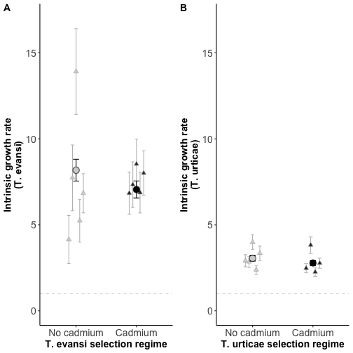

```r
## Plot---------------------------
plot_grid(Te_gr_ev_N, Tu_gr_ev_N, labels=c("A", "B"))
```

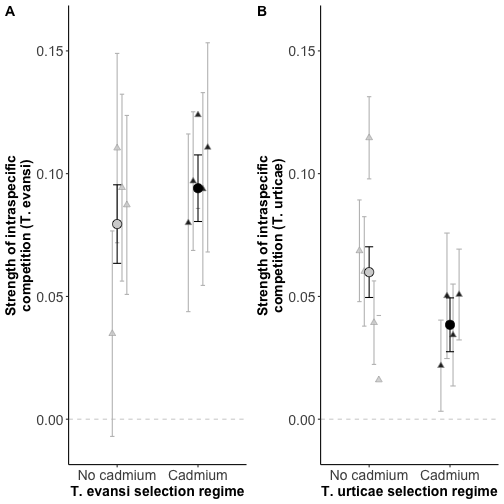

```r
save_plot("./Plots/FigS8.pdf", width=30, height=15)
save_plot("./Plots/FigS8.png", width=30, height=15)

plot_grid(Te_intra_ev_N, Tu_intra_ev_N, labels=c("A", "B"))
```

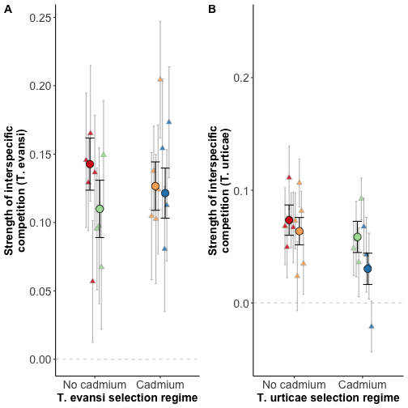

```r
save_plot("./Plots/FigS5.pdf", width=30, height=15)
save_plot("./Plots/FigS5.png", width=30, height=15)

plot_grid(Te_inter_ev_N, Tu_inter_ev_N, labels=c("A", "B"))
```

```r
save_plot("./Plots/FigS6.pdf", width=30, height=15)
save_plot("./Plots/FigS6.png", width=30, height=15)
```

```r
# Figure S9------
```

### Importing parameters

```r
## Importing parameters ---------------------------
struct_mat_REP_final2<-read.csv("./Analyses/min_distance_pooled.csv")
struct_mat_w0_final<-read.csv("./Analyses/min_distance_per_replicate.csv")
```

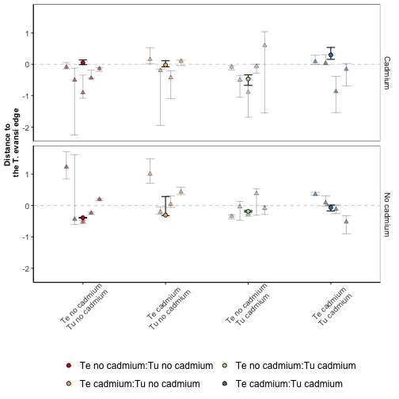

```r
## Plot ---------------------------
# first part of the plot
ggplot_distTe<-ggplot(struct_mat_REP_final2, aes(x=interaction(Tu_Regime, Te_Regime), fill=interaction(Tu_Regime, Te_Regime)))+
  facet_grid(Environment~., labeller=labeller(Environment=Env))+
  geom_hline(yintercept = 0, colour="lightgrey", linetype="dashed")+
  geom_errorbar(data=struct_mat_w0_final, aes(ymin=Te_distance_lower, ymax=Te_distance_upper), width=0.5, position=position_dodge2(0.5), alpha=0.25)+
  geom_point(data=struct_mat_w0_final, size=1.5, shape=24, position=position_dodge2(0.5), colour="black", alpha=0.55, aes(y=Te_distance))

# second part of the plot
ggplot_distTe<-ggplot_distTe +  geom_errorbar(data=struct_mat_REP_final2, aes(ymin=Te_distance_lower, ymax=Te_distance_upper, y=Te_distance), width=0.1, position=position_dodge(1))+
  geom_point(data=struct_mat_REP_final2, size=2, position=position_dodge(1), shape=21, colour="black", aes(y=Te_distance))+
  theme_bw()+
  theme_plots+
  scale_x_discrete(labels=c("Te no cadmium\nTu no cadmium","Te cadmium\nTu no cadmium","Te no cadmium\nTu cadmium","Te cadmium\nTu cadmium"))+
  ylab("Distance to \n the T. evansi edge")+
  scale_fill_brewer(palette = "Spectral", labels=c("Te no cadmium:Tu no cadmium", "Te cadmium:Tu no cadmium", "Te no cadmium:Tu cadmium", "Te cadmium:Tu cadmium"), name="")+
  guides(fill=guide_legend(nrow=2))+
  xlab("")+
  theme(legend.position = "bottom", strip.background =element_rect(colour="white"), panel.border = element_rect(colour="black"), axis.text.x = element_text(size=10, angle = 45, vjust = 0.63), strip.text = element_text(size=10), axis.text.y=element_text(size=10), axis.title = element_text(size=10, face="bold"))

ggplot_distTe
```

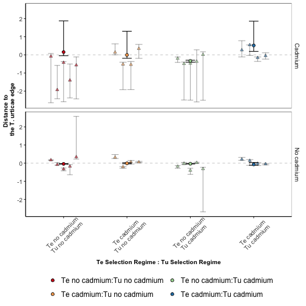

```r
# first part of the plot
ggplot_distTu<-ggplot(struct_mat_REP_final2, aes(x=interaction(Tu_Regime, Te_Regime), fill=interaction(Tu_Regime, Te_Regime)))+
  facet_grid(Environment~., labeller=labeller(Environment=Env))+
  geom_hline(yintercept = 0, colour="lightgrey", linetype="dashed")+
  geom_errorbar(data=struct_mat_w0_final, aes(ymin=Tu_distance_lower, ymax=Tu_distance_upper), width=0.5, position=position_dodge2(width=0.5), alpha=0.35)+
  geom_point(data=struct_mat_w0_final, size=1.5, shape=24, position=position_dodge2(width=0.5), colour="black", alpha=0.55, aes(y=Tu_distance))

# second part of the plot
ggplot_distTu<-ggplot_distTu+ geom_errorbar(data=struct_mat_REP_final2, aes(ymin=Tu_distance_lower, ymax=Tu_distance_upper), width=0.15)+
  geom_point(data=struct_mat_REP_final2, size=2, shape=21, colour="black", aes(y=Tu_distance))+
  theme_bw()+
  theme_plots+
  scale_x_discrete(labels=c("Te no cadmium\nTu no cadmium","Te cadmium\nTu no cadmium","Te no cadmium\nTu cadmium","Te cadmium\nTu cadmium"))+
  ylab("Distance to \n the T. urticae edge")+
  scale_fill_brewer(palette = "Spectral", labels=c("Te no cadmium:Tu no cadmium", "Te cadmium:Tu no cadmium", "Te no cadmium:Tu cadmium", "Te cadmium:Tu cadmium"), name="")+
  guides(fill=guide_legend(nrow=2))+
  xlab("Te Selection Regime : Tu Selection Regime")+
  theme(legend.position = "bottom", strip.background =element_rect(colour="white"), panel.border = element_rect(colour="black"), axis.text.x = element_text(size=10, angle = 45, vjust = 0.63), strip.text = element_text(size=10), axis.text.y=element_text(size=10), axis.title = element_text(size=10, face="bold"))

ggplot_distTu
```

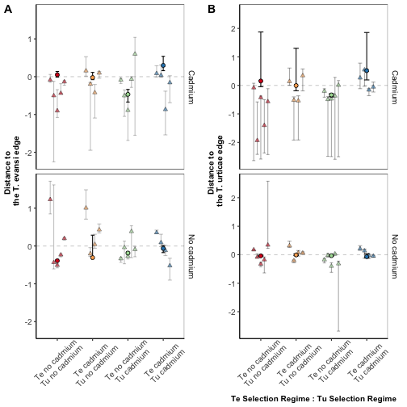

```r
# joining the two plots
plot_grid(ggplot_distTe + theme(legend.position="none"),ggplot_distTu + theme(legend.position="none"), ncol=2, labels=c("A", "B") )
```

```r
save_plot("./Plots/FigS9.pdf", width=25, height=15)
save_plot("./Plots/FigS9.png", width=25, height=15)
```